# Reporte análisis de factores

David Flores

2026-07-02

# Análisis de factores

Lo primero que se hace es cargar todas las librerías y asignar la base de datos a un objeto

```r
pg_especies<-pgfull[,1:54]
```

Posteriormente a la base datos se omiten las últimas columnas dado que para esto necesitamos variables numéricas, la base de datos consiste en observaciones de especies en parcelas, las últimas columnas corresponden a variables ambientales por lo que no serán útiles hasta el final del análisis.

```r
BARTLETT(pg_especies)
```

```
## ℹ 'x' was not a correlation matrix. Correlations are found from entered raw data.
```

```
##
## ✔ The Bartlett's test of sphericity was significant at an alpha level of .05.
##   These data are probably suitable for factor analysis.
##
##   𝜒²(1431) = 3991.52, p < .001
```

```r
KMO(pg_especies)
```

```
## ℹ 'x' was not a correlation matrix. Correlations are found from entered raw data.
```

```
##
## ── Kaiser-Meyer-Olkin criterion (KMO) ──────────────────────────────────────────
##
## ✖ The overall KMO value for your data is miserable.
##   These data are hardly suitable for factor analysis.
##
##   Overall: 0.575
##
##   For each variable:
##    AC    AE    AM    AO    AP    AR    AS    AU    BH    BM    CC    CF    CM
## 0.477 0.622 0.586 0.364 0.664 0.369 0.630 0.315 0.400 0.812 0.648 0.508 0.502
##    CN    CX    CY    DC    DG    ER    FM    FP    FR    GV    HI    HL    HP
## 0.568 0.440 0.626 0.251 0.755 0.587 0.419 0.592 0.372 0.271 0.471 0.210 0.657
##    HS    HR    KA    LA    LC    LH    LM    LO    LP    OR    PL    PP    PS
## 0.729 0.422 0.603 0.399 0.736 0.697 0.258 0.708 0.757 0.310 0.527 0.701 0.734
##    PT    QR    RA    RB    RC    SG    SM    SO    TF    TG    TO    TP    TR
## 0.716 0.573 0.641 0.562 0.566 0.486 0.534 0.491 0.698 0.665 0.716 0.642 0.385
##    VC    VK
## 0.464 0.728
```

```r
ani<-antiImage(pg_especies)
print(ani,digits=3)
```

[output not shown]

[output cut: 334 more lines]

[output not shown]

Una vez hecho esto empezaremos con las pruebas, para empezar la prueba de *BARTLETT* que es una prueba de esfericidad, lo que nos dice es si las correlaciones sin significativas, su resultado es significativo lo que demuestra que la base de datos se le puede aplicar un análisis de factores.  
La prueba de KMO nos da un valor en el cual se puede determinar si la base de datos se le puede aplicar un análisis de factores, mientras más cercano a 1 sea el KMO es mejor, sin embargo en el resultado de nuestra prueba el KMO es de 0.5 aproximadamente lo que nos indica que los datos no son óptimos para este tipo de análisis.

```r
PARALLEL(pg_especies,eigen_type="SMC")
```

```
## ℹ 'x' was not a correlation matrix. Correlations are found from entered raw data.
```

```
## Parallel Analysis performed using 1000 simulated random data sets
## Eigenvalues were found using SMC
##
## Decision rule used: means
##
## ── Number of factors to retain according to ────────────────────────────────────
##
## • SMC-determined eigenvalues:  10
```

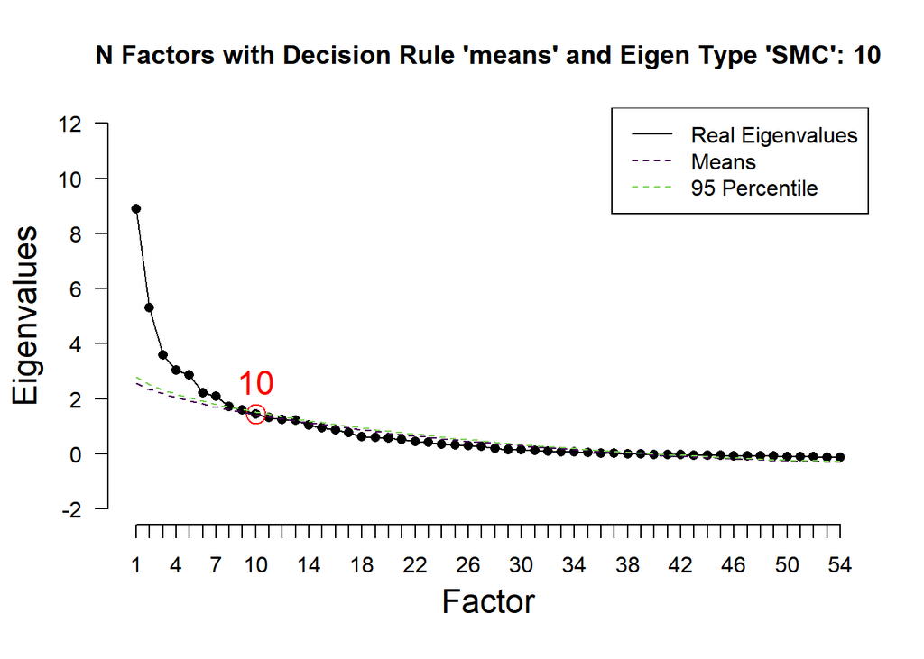

```r
N_FACTORS(pg_especies,criteria=c("PARALLEL","EKC","SMT"),
                       eigen_type_other = c("SMC","PCA"))
```

```
##
## ── Tests for the suitability of the data for factor analysis ───────────────────
##
## Bartlett's test of sphericity
##
## ✔ The Bartlett's test of sphericity was significant at an alpha level of .05.
##   These data are probably suitable for factor analysis.
##
##   𝜒²(1431) = 3991.52, p < .001
##
## Kaiser-Meyer-Olkin criterion (KMO)
##
## ✖ The overall KMO value for your data is miserable with 0.575.
##   These data are hardly suitable for factor analysis.
##
## ── Number of factors suggested by the different factor retention criteria ──────
##
## • EKC (original implementation, type 'BvA2017'): 17
## • Parallel analysis with PCA: 7
## • Parallel analysis with SMC: 10
## • Sequential 𝜒² model tests: NA
## • Lower bound of RMSEA 90% confidence interval: NA
## • Akaike Information Criterion: 23
```

A pesar de que los datos no son óptimos para este tipo de análisis, se hacen las pruebas de *PARALLEL* que compara los eigenvalores obtenidos de la mariz de correlaciones y las compara con un amtriz nula, se le aplica el método SMC el cual usa correlaciones cudradas mínimas como estimadores y esta prueba se usa para retener factores, pero no funciona muy bien para factores altamente correlacionados. *N_FACTORS* es una función con la que puedes ejecutar múltiples criterios para evaluar la retención de factores, además de que revisa los datos para saber si se le puede aplicar un análisis de factores.  
El resultado de estas pruebas nos arrojan que la cantidad de factores necesarios para estos datos son 7 o 10, para esto haremos con 7 factores.

```r
EFA(pg_especies,n_factors= 7)
```

```
## ℹ 'x' was not a correlation matrix. Correlations are found from entered raw data.
```

```
##
## EFA performed with type = 'EFAtools', method = 'PAF', and rotation = 'none'.
##
## ── Model Diagnostics ───────────────────────────────────────────────────────────
##
## Factors: 7
## Variables: 54
## N: 89
## Heywood cases: 0
## Cross-loading items (|loading| >= .300): 27
## Items without salient loading (|loading| >= .300): 6
## Factors with fewer than 3 salient indicators: 0
## Items with primary-loading gap < .200: 23
## Largest |residual|: .461
##
## ── Unrotated Loadings ──────────────────────────────────────────────────────────
##
##      F1     F2     F3     F4     F5     F6     F7     h2     u2
## AC   .272  -.410  -.305   .188   .067   .049   .012   .378   .622
## AE  -.750   .225   .420  -.044   .125   .124   .011   .822   .178
## AM   .371   .373  -.321   .125  -.050   .212  -.144   .464   .536
## AO   .025  -.357  -.056   .102  -.231  -.170  -.049   .226   .774
## AP  -.692   .067   .417  -.020   .101   .103  -.021   .679   .321
## AR   .084   .186   .235  -.012   .032   .013  -.013   .098   .902
## AS  -.606   .270   .436  -.106   .099   .137   .020   .670   .330
## AU   .128  -.071  -.132   .029  -.126   .899   .048   .866   .134
## BH  -.328   .160   .219  -.014   .069   .095   .006   .196   .804
## BM   .647   .326   .342  -.087   .130  -.062   .197   .709   .291
## CC   .356  -.125  -.202  -.076   .699   .115  -.219   .739   .261
## CF   .054   .541   .064   .286  -.020  -.024  -.292   .468   .532
## CM  -.038   .136  -.432  -.210   .028   .083   .152   .281   .719
## CN   .446  -.019  -.212  -.083   .538   .008  -.195   .579   .421
## CX   .406   .096   .194  -.008   .448  -.033   .242   .472   .528
## CY   .467  -.028   .208  -.009   .161  -.029   .303   .380   .620
## DC   .093  -.109  -.126  -.038   .518   .011  -.093   .315   .685
## DG  -.534   .211   .296  -.083   .382   .126  -.162   .612   .388
## ER  -.085   .325  -.162   .775   .110  -.067   .130   .773   .227
## FM   .105  -.057  -.033   .012   .051   .024  -.065   .023   .977
## FP   .031   .520   .114   .357   .088  -.033   .126   .436   .564
## FR   .308  -.180  -.002   .039  -.166  -.003  -.027   .157   .843
```

[output cut: 95 more lines]

```
## Largest absolute residual: .461
##
## Largest residuals (top 10 of 112):
## • RB ~~ SM: .461
## • HI ~~ HR: .445
## • FR ~~ RC: .436
## • AR ~~ CF: .400
## • CX ~~ DC: .357
## • AO ~~ QR: .344
## • FR ~~ GV: .300
## • CC ~~ LA: .280
## • CN ~~ DC: .279
## • AO ~~ FR: -.268
##
## Inspect the residual matrix for details (e.g., with residuals()).
```

```r
Factores<-EFA(pg_especies,n_factors=7)
```

```
## ℹ 'x' was not a correlation matrix. Correlations are found from entered raw data.
```

```r
F1<-Factores$unrot_loadings[,1]
F2<-Factores$unrot_loadings[,2]
F3<-Factores$unrot_loadings[,3]
F4<-Factores$unrot_loadings[,4]
F5<-Factores$unrot_loadings[,5]
F6<-Factores$unrot_loadings[,6]
F7<-Factores$unrot_loadings[,7]

Facts<-data.frame(F1,F2,F3,F4,F5,F6,F7)
view(Facts)
vars<-rownames(Facts)
Facts<-mutate(Facts,vars=vars)
```

Asignamos cada factor a un objeto y lo unimos en un data frame que al final obtenemos una columna más con los nombres de las especies

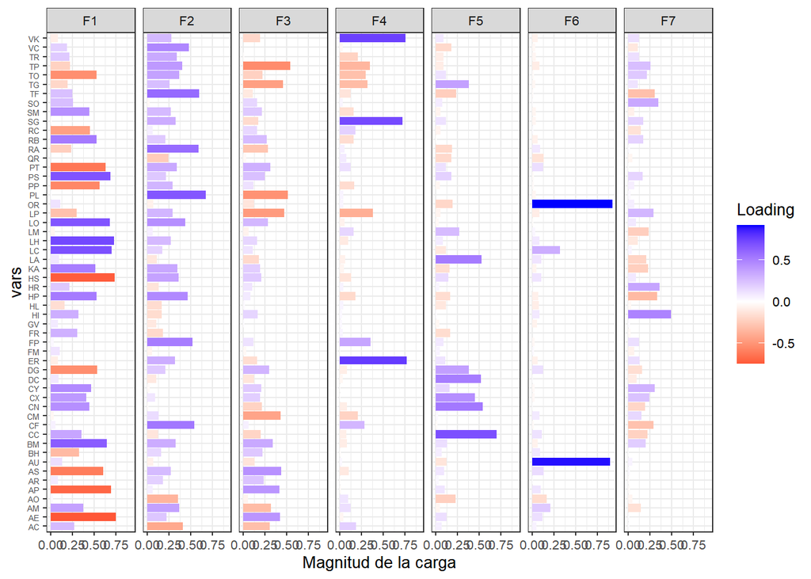

```r
Facts2 <- melt(Facts, id="vars",
               measure=c("F1","F2","F3","F4","F5","F6","F7"),
               variable.name="Factor", value.name="Loading")

view(Facts2)

ggplot(Facts2, aes(x= vars, y = abs(Loading), fill=Loading)) +
  facet_wrap(~ Factor, nrow=1) +
  geom_bar(stat="identity") +
  coord_flip() +
  scale_fill_gradient2(name = "Loading",
                       high = "blue", mid = "white", low = "red",
                       midpoint=0) +
  ylab("Magnitud de la carga") +
  theme_bw(base_size=10)+
  theme(axis.text.y=element_text(size=5))
```

Con este gráfico podemos observar la relación entre factores y abundancia de cada una de las especies, mientras más fuerte sea el color ya sea rojo o azul tendrá una ausencia o presencia marcada respectivamente. En el gráfico se observa que para el factor 1 hay varias especies que están presentes cuando el factor 1 está ahí por ejemplo *LO, LH, LC y PS*, pero al contrario hay otras especies que no están presentes con el factor 1 como *PT, PP, DG, AS, AP, y AE* dado que estás tienen una relación inversa, aquellas que presentan un color más tenue la relación es más cercana a 0 lo que puede indicar que no dependen que el factor este presente para determinar su presencia o ausencia.

```r
vmx1<-EFA(pg_especies, n_factors = 7, rotation = "varimax")
```

```
## ℹ 'x' was not a correlation matrix. Correlations are found from entered raw data.
```

```r
vmx1
```

```
##
## EFA performed with type = 'EFAtools', method = 'PAF', and rotation = 'varimax'.
##
## ── Model Diagnostics ───────────────────────────────────────────────────────────
##
## Factors: 7
## Variables: 54
## N: 89
## Heywood cases: 0
## Cross-loading items (|loading| >= .300): 12
## Items without salient loading (|loading| >= .300): 5
## Factors with fewer than 3 salient indicators: 0
## Items with primary-loading gap < .200: 14
## Largest |residual|: .461
##
## ── Rotated Loadings ────────────────────────────────────────────────────────────
##
##      F2     F1     F3     F4     F7     F5     F6     h2     u2
## AC  -.247  -.500  -.089   .052   .065   .194   .119   .378   .622
## AE  -.193   .868  -.043   .001  -.114  -.128  -.030   .822   .178
## AM   .405  -.254   .199   .280  -.137   .132   .285   .464   .536
## AO  -.218  -.302  -.182  -.069  -.079  -.177  -.108   .226   .774
## AP  -.260   .749  -.140  -.050  -.112  -.120  -.037   .679   .321
## AR   .240   .155  -.093   .018   .086  -.005  -.018   .098   .902
## AS  -.059   .803  -.030  -.045  -.059  -.124  -.005   .670   .330
## AU  -.020  -.047  -.001  -.041   .032   .036   .927   .866   .134
## BH  -.037   .435  -.019   .023  -.039  -.050   .020   .196   .804
## BM   .648  -.072  -.082   .013   .512   .103  -.065   .709   .291
## CC   .049  -.174  -.004  -.049   .080   .834   .046   .739   .261
## CF   .437   .161  -.051   .422  -.264   .016  -.026   .468   .532
## CM  -.045  -.089   .502  -.024  -.030   .064   .116   .281   .719
## CN   .191  -.258   .044  -.020   .075   .684  -.023   .579   .421
## CX   .242   .001  -.046   .061   .518   .365  -.083   .472   .528
## CY   .219  -.158  -.107  -.018   .532   .108  -.024   .380   .620
## DC  -.089  -.025   .024  -.014   .063   .547  -.053   .315   .685
## DG  -.090   .725  -.039  -.015  -.150   .228  -.042   .612   .388
## ER  -.066   .031  -.009   .876   .008  -.005  -.024   .773   .227
## FM   .022  -.095  -.048  -.013  -.007   .100   .028   .023   .977
## FP   .292   .230   .041   .529   .119  -.036  -.040   .436   .564
## FR   .080  -.330  -.160  -.070   .063  -.065   .058   .157   .843
```

[output cut: 94 more lines]

```
## Largest absolute residual: .461
##
## Largest residuals (top 10 of 112):
## • RB ~~ SM: .461
## • HI ~~ HR: .445
## • FR ~~ RC: .436
## • AR ~~ CF: .400
## • CX ~~ DC: .357
## • AO ~~ QR: .344
## • FR ~~ GV: .300
## • CC ~~ LA: .280
## • CN ~~ DC: .279
## • AO ~~ FR: -.268
##
## Inspect the residual matrix for details (e.g., with residuals()).
```

```r
final<-factanal(pg_especies,factors=7,rotation="varimax",scores="regression")
Factor1<-final$scores[,1]
Factor2<-final$scores[,2]
Factor3<-final$scores[,3]
Factor4<-final$scores[,4]
Factor5<-final$scores[,5]
Factor6<-final$scores[,6]
Factor7<-final$scores[,7]
ambientales<-pgfull[,57:59]
cor(Factor1,ambientales)
```

```
##        species        hay        pH
## [1,] 0.6635773 -0.3178595 0.4462418
```

```r
cor(Factor2,ambientales)
```

```
##          species       hay        pH
## [1,] -0.07480179 0.5804016 0.4869059
```

```r
cor(Factor3,ambientales)
```

```
##        species       hay        pH
## [1,] 0.2536944 0.2799525 0.3024642
```

```r
cor(Factor4,ambientales)
```

```
##        species       hay         pH
## [1,] 0.1057842 0.1149473 0.08507437
```

```r
cor(Factor5,ambientales)
```

```
##        species       hay        pH
## [1,] 0.2329568 0.0762982 0.1935713
```

```r
cor(Factor6,ambientales)
```

```
##       species        hay        pH
## [1,] 0.226808 -0.1736003 0.1267656
```

```r
cor(Factor7,ambientales)
```

```
##         species         hay          pH
## [1,] 0.04873965 -0.03626301 -0.01242736
```